# Song Data Project

Kristian Abad & Steven Truong

2/13/2022

# Introduction

The purpose of this project is to observe the relationship between the popularity of songs based on its characteristics and generate a model that will predict the song’s popularity based on given characteristics.

# What Are The Characteristics Of Music?

The characteristics of music are the audio features of a song. In our dataset, we were given numeric data for features such as the song’s duration, acousticness, danceability, energy, instrumentalness, key, liveliness, loudness, audio mode, speechiness, tempo, time signature, and audio valence. The combination of these audio features makes up what we hear. According to Spotify APIs, these features can be categorized in which aspect of a song that it can affect:

- Mood: Danceability, Valence, Energy, Tempo
- Properties: Loudness, Speechiness, Instrumentalness
- Context: Liveness, Acousticness

We were also given a descriptions and range of unit of each audio feature:

- Duration: The duration of the track in milliseconds.
- Acousticness: A confidence measure from 0.0 to 1.0 of whether the track is acoustic. 1.0 represents high confidence the track is acoustic.
- Danceability: Describes how suitable a track is for dancing based on a combination of musical elements including tempo, rhythm stability, beat strength, and overall regularity. A value of 0.0 is least danceable and 1.0 is most danceable.
- Energy: A measure from 0.0 to 1.0 and represents a perceptual measure of intensity and activity. Typically, energetic tracks feel fast, loud, and noisy. For example, death metal has high energy, while a Bach prelude scores low on the scale. Perceptual features contributing to this attribute include dynamic range, perceived loudness, timbre, onset rate, and general entropy.
- Instrumentalness: Predicts whether a track contains no vocals. “Ooh” and “aah” sounds are treated as instrumental in this context. Rap or spoken word tracks are clearly “vocal”. The closer the instrumentalness value is to 1.0, the greater likelihood the track contains no vocal content. Values above 0.5 are intended to represent instrumental tracks, but confidence is higher as the value approaches 1.0.
- Key: The key the track is in. Integers map to pitches using standard Pitch Class notation. E.g. 0 = C, 1 = C♯/D♭, 2 = D, and so on. If no key was detected, the value is -1.
- Liveliness: Detects the presence of an audience in the recording. Higher liveness values represent an increased probability that the track was performed live. A value above 0.8 provides strong likelihood that the track is live.
- Loudness: The overall loudness of a track in decibels (dB). Loudness values are averaged across the entire track and are useful for comparing relative loudness of tracks. Loudness is the quality of a sound that is the primary psychological correlate of physical strength (amplitude). Values typically range between -60 and 0 db.
- Mode: Mode indicates the modality (major or minor) of a track, the type of scale from which its melodic content is derived. Major is represented by 1 and minor is 0.
- Speechiness: Detects the presence of spoken words in a track. The more exclusively speech-like the recording (e.g. talk show, audio book, poetry), the closer to 1.0 the attribute value. Values above 0.66 describe tracks that are probably made entirely of spoken words. Values between 0.33 and 0.66 describe tracks that may contain both music and speech, either in sections or layered, including such cases as rap music. Values below 0.33 most likely represent music and other non-speech-like tracks.
- Tempo: The overall estimated tempo of a track in beats per minute (BPM). In musical terminology, tempo is the speed or pace of a given piece and derives directly from the average beat duration.
- Time Signature: An estimated time signature. The time signature (meter) is a notational convention to specify how many beats are in each bar (or measure). The time signature ranges from 3 to 7 indicating time signatures of “3/4”, to “7/4”.
- Valence: A measure from 0.0 to 1.0 describing the musical positiveness conveyed by a track. Tracks with high valence sound more positive (e.g. happy, cheerful, euphoric), while tracks with low valence sound more negative (e.g. sad, depressed, angry).

In addition to the audio feature, the dataset also provided the name of songs and how it ranked in popularity from a range of 0 to 100 (where 0 is the lowest popularity and 100 is the highest popularity).

# Why Might The Model Be Useful?

It is in the interest of music artists and companies to produce songs that will rank high in popularity and top the charts. By having some knowledge of what music listeners generally enjoy, artists will be able to incorporate more of what people want and this will lead to a higher success of the song.

# Loading Data and Packages

```r
library(readr)
library(tidyr)
library(tidyverse)
library(ggplot2)
library(dplyr)
library(class)
library(FNN)
library(glmnet)
```

# Data Cleaning

When observing the raw dataset, we saw that they are multiple songs that are repeated. We assumed that there was some error in the raw data, so we decided to get rid of the duplicate. However, some songs have the same title, but they have different popularity scores and audio features values. We decided to leave those data assuming that they are remixes.

```r
data = read_csv("data/song_data.csv")
head(data)
```

```
## # A tibble: 6 x 15
##   song_name    song_popularity song_duration_ms acousticness danceability energy
##   <chr>                  <dbl>            <dbl>        <dbl>        <dbl>  <dbl>
## 1 Boulevard o~              73           262333     0.00552         0.496  0.682
## 2 In The End                66           216933     0.0103          0.542  0.853
## 3 Seven Natio~              76           231733     0.00817         0.737  0.463
## 4 By The Way                74           216933     0.0264          0.451  0.97
## 5 How You Rem~              56           223826     0.000954        0.447  0.766
## 6 Bring Me To~              80           235893     0.00895         0.316  0.945
## # ... with 9 more variables: instrumentalness <dbl>, key <dbl>, liveness <dbl>,
## #   loudness <dbl>, audio_mode <dbl>, speechiness <dbl>, tempo <dbl>,
## #   time_signature <dbl>, audio_valence <dbl>
```

One challenge we need to figure out is addressing the following cases in our data, if there are any:

- Remixes
- Remasters
- Single Versions
- Same name but different artists?
- Radio edits
- Extended versions
- Misc mixes/versions  
  I think maybe we can leave remixes possibly treating them as reimaginings of songs or somewhat to the same vein that songs have samples from other tracks are in themselves a separate track. Maybe the more difficult is dealing with the other cases. An example that comes to mind is “Smooth Operator” by Sade (seems like only one of the 3 versions is in the data). There’s a single version, a remastered version, and I believe an album version where there’s an immediate difference between the remastered and album version.  
  I think the duplicated() function finds exact duplicates of rows.

```r
duplicates <- data[duplicated(data),]
duplicates
```

```
## # A tibble: 3,909 x 15
##    song_name   song_popularity song_duration_ms acousticness danceability energy
##    <chr>                 <dbl>            <dbl>        <dbl>        <dbl>  <dbl>
##  1 Sex on Fire              81           203346      0.00172        0.542  0.905
##  2 Use Somebo~              79           230760      0.00552        0.276  0.715
##  3 Hips Don't~              84           218093      0.284          0.778  0.824
##  4 Hotel Cali~              83           391376      0.00574        0.579  0.508
##  5 Me and Bob~              69           271333      0.302          0.453  0.464
##  6 Imagine - ~              77           187866      0.907          0.547  0.257
##  7 Let It Be ~              78           243026      0.631          0.443  0.403
##  8 Rocket Man~              80           281613      0.386          0.602  0.522
##  9 My Sweet L~              78           281226      0.0794         0.538  0.704
## 10 Tangled up~              63           341626      0.414          0.421  0.661
## # ... with 3,899 more rows, and 9 more variables: instrumentalness <dbl>,
## #   key <dbl>, liveness <dbl>, loudness <dbl>, audio_mode <dbl>,
## #   speechiness <dbl>, tempo <dbl>, time_signature <dbl>, audio_valence <dbl>
```

Just testing some cases here…while scrolling through on kaggle, I just picked a random duplicate song to test

```r
duplicates %>%
  filter(song_name == 'Zombie')
```

```
## # A tibble: 1 x 15
##   song_name song_popularity song_duration_ms acousticness danceability energy
##   <chr>               <dbl>            <dbl>        <dbl>        <dbl>  <dbl>
## 1 Zombie                 82           306410       0.0163        0.299  0.613
## # ... with 9 more variables: instrumentalness <dbl>, key <dbl>, liveness <dbl>,
## #   loudness <dbl>, audio_mode <dbl>, speechiness <dbl>, tempo <dbl>,
## #   time_signature <dbl>, audio_valence <dbl>
```

Here’s an interesting case where we have 2 of the same rows and 1 with a remix with a track called “8 Letters”

```r
duplicates %>%
  filter(song_name == '8 Letters')
```

```
## # A tibble: 1 x 15
##   song_name song_popularity song_duration_ms acousticness danceability energy
##   <chr>               <dbl>            <dbl>        <dbl>        <dbl>  <dbl>
## 1 8 Letters              72           190026        0.649        0.607  0.478
## # ... with 9 more variables: instrumentalness <dbl>, key <dbl>, liveness <dbl>,
## #   loudness <dbl>, audio_mode <dbl>, speechiness <dbl>, tempo <dbl>,
## #   time_signature <dbl>, audio_valence <dbl>
```

```r
duplicates %>%
  filter(song_name == '8 Letters - R3HAB Remix')
```

```
## # A tibble: 0 x 15
## # ... with 15 variables: song_name <chr>, song_popularity <dbl>,
## #   song_duration_ms <dbl>, acousticness <dbl>, danceability <dbl>,
## #   energy <dbl>, instrumentalness <dbl>, key <dbl>, liveness <dbl>,
## #   loudness <dbl>, audio_mode <dbl>, speechiness <dbl>, tempo <dbl>,
## #   time_signature <dbl>, audio_valence <dbl>
```

So it looks like it just picks up exact duplicates and we’ll need to figure out what we’re going to do with other cases.

```r
data_2 <- data[!duplicated(data),]
nrow(data)
```

```
## [1] 18835
```

```r
nrow(data_2)
```

```
## [1] 14926
```

```r
nrow(data) - nrow(data_2)
```

```
## [1] 3909
```

Using the grepl function to find any instance of single,remastered, and radio edit/mix versions of tracks.

```r
#Function was found via stackoverflow
#https://stackoverflow.com/questions/10128617/test-if-characters-are-in-a-string
data_3 <- data_2[!(grepl('Single',data_2$song_name,fixed=TRUE) |
                 grepl('Remaster',data_2$song_name,fixed=TRUE) |
                 grepl('Radio',data_2$song_name,fixed=TRUE)),]
data_3
```

```
## # A tibble: 14,276 x 15
##    song_name   song_popularity song_duration_ms acousticness danceability energy
##    <chr>                 <dbl>            <dbl>        <dbl>        <dbl>  <dbl>
##  1 Boulevard ~              73           262333     0.00552         0.496  0.682
##  2 In The End               66           216933     0.0103          0.542  0.853
##  3 Seven Nati~              76           231733     0.00817         0.737  0.463
##  4 By The Way               74           216933     0.0264          0.451  0.97
##  5 How You Re~              56           223826     0.000954        0.447  0.766
##  6 Bring Me T~              80           235893     0.00895         0.316  0.945
##  7 Last Resort              81           199893     0.000504        0.581  0.887
##  8 Are You Go~              76           213800     0.00148         0.613  0.953
##  9 Mr. Bright~              80           222586     0.00108         0.33   0.936
## 10 Sex on Fire              81           203346     0.00172         0.542  0.905
## # ... with 14,266 more rows, and 9 more variables: instrumentalness <dbl>,
## #   key <dbl>, liveness <dbl>, loudness <dbl>, audio_mode <dbl>,
## #   speechiness <dbl>, tempo <dbl>, time_signature <dbl>, audio_valence <dbl>
```

Checking for missing values

```r
data_3[is.na(data_3)]
```

```
## <unspecified> [0]
```

```r
#data_3[grepl('Swimming Pools (Drank)',data_3$song_name,fixed=TRUE),]


#This is the only entry for this song in the dataset
#data_3[grepl("Wouldn't It Be Nice",data_3$song_name,fixed=TRUE),]
#nrow(data_3)
data_4 <- data_3[!(grepl('Mix',data_3$song_name,fixed=TRUE) |
       grepl('Version',data_3$song_name,fixed=TRUE)),]
data_4
```

```
## # A tibble: 14,050 x 15
##    song_name   song_popularity song_duration_ms acousticness danceability energy
##    <chr>                 <dbl>            <dbl>        <dbl>        <dbl>  <dbl>
##  1 Boulevard ~              73           262333     0.00552         0.496  0.682
##  2 In The End               66           216933     0.0103          0.542  0.853
##  3 Seven Nati~              76           231733     0.00817         0.737  0.463
##  4 By The Way               74           216933     0.0264          0.451  0.97
##  5 How You Re~              56           223826     0.000954        0.447  0.766
##  6 Bring Me T~              80           235893     0.00895         0.316  0.945
##  7 Last Resort              81           199893     0.000504        0.581  0.887
##  8 Are You Go~              76           213800     0.00148         0.613  0.953
##  9 Mr. Bright~              80           222586     0.00108         0.33   0.936
## 10 Sex on Fire              81           203346     0.00172         0.542  0.905
## # ... with 14,040 more rows, and 9 more variables: instrumentalness <dbl>,
## #   key <dbl>, liveness <dbl>, loudness <dbl>, audio_mode <dbl>,
## #   speechiness <dbl>, tempo <dbl>, time_signature <dbl>, audio_valence <dbl>
```

# Train/Test Split

Here we do a 80% random split for the training set and save the remaining 20% for the test 20%.

```r
set.seed(131)
train_1 = sample(1:nrow(data_4), 11240)
music.train = data_4[train_1,]
music.test = data_4[-train_1,]

cat('Rows in training set:',nrow(music.train),'\n')
```

```
## Rows in training set: 11240
```

```r
cat('Rows in test set: ',nrow(music.test),'\n')
```

```
## Rows in test set:  2810
```

# Exploratory Data Analysis

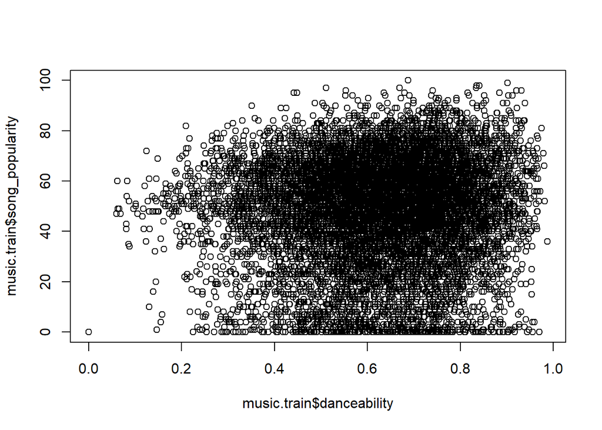

```r
plot(music.train$danceability,music.train$song_popularity)
```

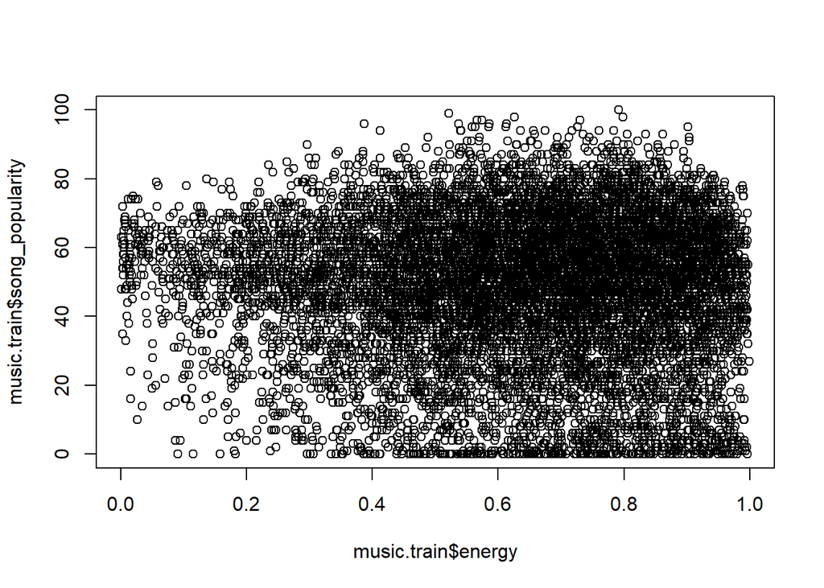

```r
plot(music.train$energy,music.train$song_popularity)
```

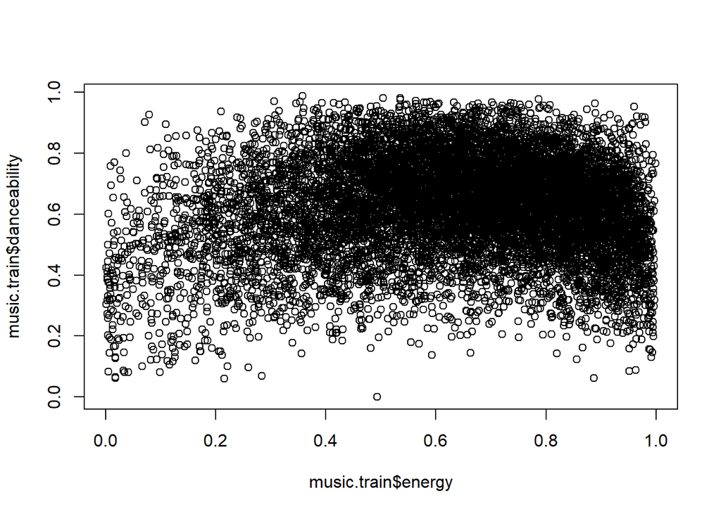

```r
plot(music.train$energy,music.train$danceability)
```

When it comes to plotting song popularity against some of the other variables such as danceability and energy, there doesn’t appear to be any immediate relationship but when it comes to plotting danceability versus energy, there appears to be some quadratic relationship among the variables.

# Linear Regression

We decided to make a histogram graph of the Popularity of our songs to observe where most of the songs were ranked in term of Popularity

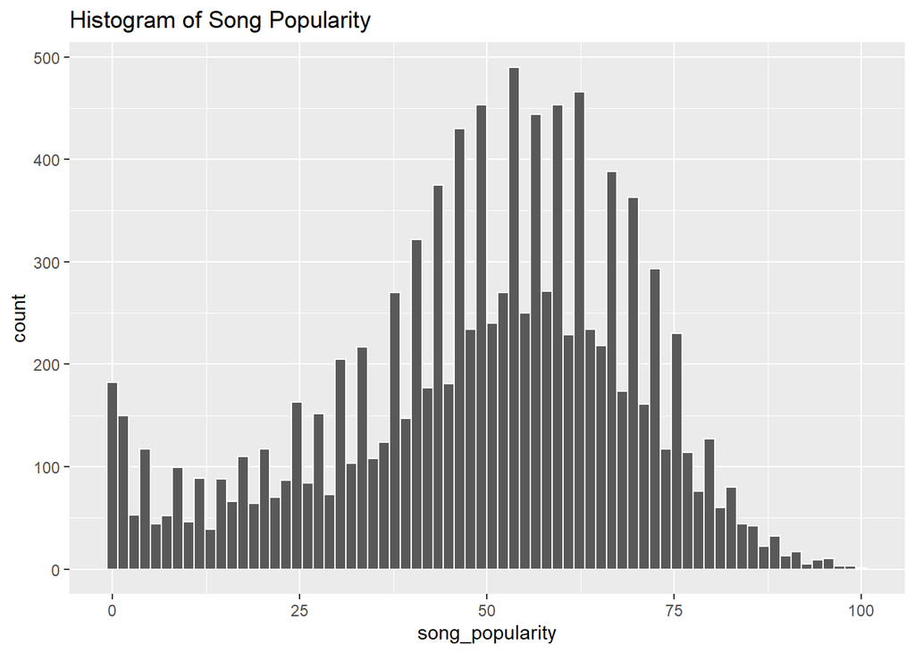

```r
ggplot(music.train, aes(song_popularity)) +
  geom_histogram(bins = 70, color = "white") +
  labs(
    title = "Histogram of Song Popularity"
  )
```

From this, we observed that most song popularity are rated in the middle where the scores are around 50 to 60 out of 100. We also see that not many songs get a score above a score of 90 out of 100. We see that there a lot more songs that are rated low popularity. We will now continue to observe the different audio features of the songs individually to see any relationship between it and the song’s popularity.

Diagnostics Test

- Linearity: evaluated by the Residuals vs Fitted plot (want horizontal line to follow assumption)
- Normality: evaluated by the Normal Q-Q plot (want y = x line to follow assumption)
- Homoscedasticity: evaluated by the Scale-location plot (want horizontal line to follow assumption)
- Influential cases (outlier): evaluated by the Residuals vs Leverage (want horizontal line to follow assumption)

```r
mod_all = lm(music.train$song_popularity ~ music.train$acousticness + music.train$danceability + music.train$instrumentalness + music.train$liveness + music.train$loudness + music.train$tempo + music.train$energy + music.train$key + music.train$speechiness)
summary(mod_all)
```

```
##
## Call:
## lm(formula = music.train$song_popularity ~ music.train$acousticness +
##     music.train$danceability + music.train$instrumentalness +
##     music.train$liveness + music.train$loudness + music.train$tempo +
##     music.train$energy + music.train$key + music.train$speechiness)
##
## Residuals:
##     Min      1Q  Median      3Q     Max
## -55.697 -11.407   3.052  14.702  49.132
##
## Coefficients:
##                                Estimate Std. Error t value Pr(>|t|)
## (Intercept)                   61.037396   2.114828  28.862  < 2e-16 ***
## music.train$acousticness      -3.080333   0.894890  -3.442 0.000579 ***
## music.train$danceability       4.056275   1.300370   3.119 0.001817 **
## music.train$instrumentalness  -6.195891   0.885224  -6.999 2.72e-12 ***
## music.train$liveness          -4.538303   1.367884  -3.318 0.000910 ***
## music.train$loudness           0.428301   0.081165   5.277 1.34e-07 ***
## music.train$tempo             -0.016558   0.006724  -2.462 0.013814 *
## music.train$energy           -11.094430   1.568623  -7.073 1.61e-12 ***
## music.train$key                0.025049   0.052961   0.473 0.636236
## music.train$speechiness       -2.543657   1.896748  -1.341 0.179927
## ---
## Signif. codes:  0 '***' 0.001 '**' 0.01 '*' 0.05 '.' 0.1 ' ' 1
##
## Residual standard error: 20.22 on 11230 degrees of freedom
## Multiple R-squared:  0.0174, Adjusted R-squared:  0.01662
## F-statistic:  22.1 on 9 and 11230 DF,  p-value: < 2.2e-16
```

```r
FinalLinearMod = lm(music.train$song_popularity ~ music.train$acousticness + music.train$danceability + music.train$instrumentalness + music.train$liveness + music.train$loudness + music.train$tempo + music.train$energy)
summary(FinalLinearMod)
```

```
##
## Call:
## lm(formula = music.train$song_popularity ~ music.train$acousticness +
##     music.train$danceability + music.train$instrumentalness +
##     music.train$liveness + music.train$loudness + music.train$tempo +
##     music.train$energy)
##
## Residuals:
##     Min      1Q  Median      3Q     Max
## -56.262 -11.408   3.045  14.728  49.266
##
## Coefficients:
##                                Estimate Std. Error t value Pr(>|t|)
## (Intercept)                   61.278308   2.097917  29.209  < 2e-16 ***
## music.train$acousticness      -3.052667   0.894630  -3.412 0.000647 ***
## music.train$danceability       3.706776   1.273006   2.912 0.003600 **
## music.train$instrumentalness  -6.152911   0.884490  -6.956 3.68e-12 ***
## music.train$liveness          -4.754466   1.358927  -3.499 0.000469 ***
## music.train$loudness           0.430241   0.081146   5.302 1.17e-07 ***
## music.train$tempo             -0.017345   0.006699  -2.589 0.009633 **
## music.train$energy           -11.106924   1.568114  -7.083 1.50e-12 ***
## ---
## Signif. codes:  0 '***' 0.001 '**' 0.01 '*' 0.05 '.' 0.1 ' ' 1
##
## Residual standard error: 20.22 on 11232 degrees of freedom
## Multiple R-squared:  0.01723,    Adjusted R-squared:  0.01662
## F-statistic: 28.13 on 7 and 11232 DF,  p-value: < 2.2e-16
```

```r
AIC(FinalLinearMod)
```

```
## [1] 99494.58
```

```r
BIC(FinalLinearMod)
```

```
## [1] 99560.52
```

The predictors of final model seem to have p-values < 0.05. From this we can establish the relationship between the predictors/characteristics and response in the mathematical formula:

Popularity = 61.278308 + -3.052667*acousticness + 3.706776*danceability + -6.152911*instrumentalness + -4.754466*liveness + 0.430241*loudness + -0.017345*tempo + -11.106924*energy

However, we noticed that our R-squared and adjusted squared value is relatively low, which might indicate that our independent variable is not explaining much in variation of our dependent variable. The Akaike Information Criterion (AIC) is a mathematical method that evaluates how well a model fits the data it was generated from. This AIC is beneficial in comparing different possible models and determine which is best fit for the data, so lower AIC is better. The Baysian Information Criteria (BIC) estimate the likelihood of a model to predict and so lower value would be better. However, our model have extremely high value AIC = 99494.58 and BIC = 99560.52, which mean our model is not fit for the data.

```r
mse = mean(FinalLinearMod$residuals^2)
mse
```

```
## [1] 408.4429
```

The MSE of our model is also very high. Since AIC, BIC, and MSE values are relatively high, we conclude that linear regression might not be the best model for predicting the popularity of songs. However, we continue to try predict music popularity with our final model.

Predicting Linear Models

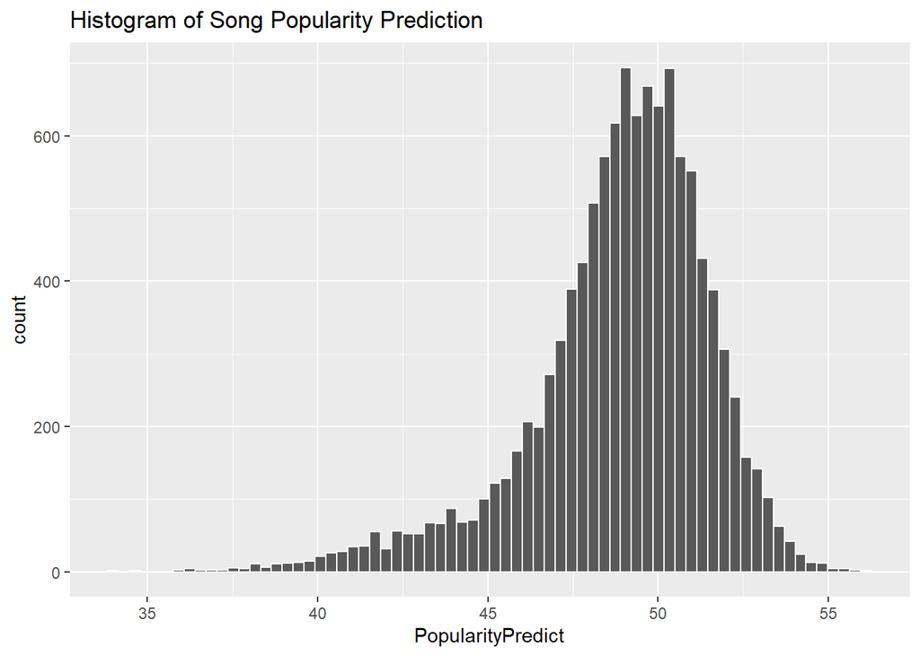

```r
PopularityPredict = predict(FinalLinearMod, music.test)
ggplot(music.train, aes(PopularityPredict)) +
  geom_histogram(bins = 70, color = "white") +
  labs(
    title = "Histogram of Song Popularity Prediction"
  )
```

We see that the prediction of song is mostly around 50 out of 100, which is a less than our Song’s Popularity plot of data from earlier where most of the score is around 50 to 60 out of 100. However, the results are very similar to the plot of predictions is very similar to the orginal raw data plot in terms of having most of the song scored in the 50 out of 100 area.

```r
different_pred = data.frame(cbind(actuals = music.test$song_popularity, predicteds = PopularityPredict))
correlation_accuracy = cor(different_pred)
correlation_accuracy
```

```
##                actuals  predicteds
## actuals    1.000000000 0.001117844
## predicteds 0.001117844 1.000000000
```

We see that our predicted values and the test values have a very low correlation accuracy with a 0.1% accuracy.

#Variation of Linear Regression

Rigdge Regression

We decided to observe a subset of our data set of size n/2. Here, we split that data set into training and testing data set.

```r
set.seed(1)
train = sample(1:nrow(data_4), nrow(data_4)/2)
test = (-train)
x = model.matrix(song_popularity ~ acousticness + danceability + instrumentalness + liveness + loudness + tempo + energy + key + speechiness, data_4)
y = data_4$song_popularity
x.train=x[train,]
y.train=y[train]
x.test=x[test,]
y.test=y[test]
```

Cross Validation to choose the Best Tuning Parameter

Instead of choosing a random lamda, we are going to use cross-validation to choose the tuning parameter lamda. We decided to do 5 folds because it was faster and similar to the result we got when we did 10 folds.

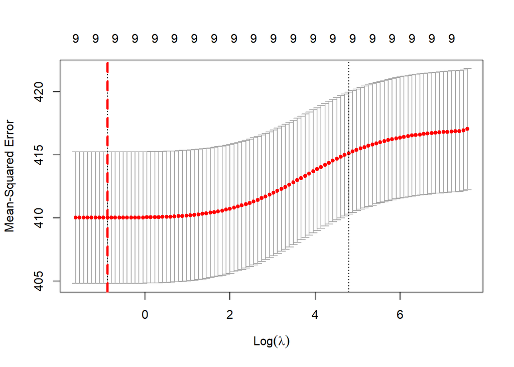

```r
set.seed(1)
cv.out.ridge=cv.glmnet(x.train, y.train, alpha = 0, nfolds = 5)
plot(cv.out.ridge)
abline(v = log(cv.out.ridge$lambda.min), col="red", lwd=3, lty=2)
```

The plot is showing the trend of mse according to our list of lamda. Our goal is to find the lamda that would give the lowest mse.

```r
bestlam = cv.out.ridge$lambda.min
bestlam
```

```
## [1] 0.4132726
```

The best lamda that will result in the smallest cross-validation error is 0.4132726. Now, we will try to find the MSE using the lamda value that we found. We decided to use the list of lamda from our homework 3.

```r
lambda.list.ridge = 1000 * exp(seq(0, log(1e-5), length = 100))
#lambda.list.ridge =  10^seq(10, -2, length = 100)
ridge.mod=glmnet(x.train,y.train,alpha=0,lambda = lambda.list.ridge)
```

The ridge testing MSE w/ best lamda

```r
ridge.pred=predict(ridge.mod,s=bestlam ,newx=x[test,])
mean((ridge.pred-y.test)^2)
```

```
## [1] 409.1103
```

The ridge testing MSE with best lamda is 409.1103

The ridge training MSE w/ best lamda

```r
ridge.pred=predict(ridge.mod,s=bestlam ,newx=x[train,])
mean((ridge.pred-y.train)^2)
```

```
## [1] 408.7107
```

The ridge training MSE with best lamda is 408.7107

We see that the MSE values are similar to the ones that we got with the linear regression.

The coefficients

```r
out = glmnet(x, y, alpha = 0, lamda = lambda.list.ridge)
predict(out,type="coefficients",s=bestlam)
```

```
## 11 x 1 sparse Matrix of class "dgCMatrix"
##                             s1
## (Intercept)       61.778434502
## (Intercept)        .
## acousticness      -3.642036429
## danceability       3.915299091
## instrumentalness  -6.486673022
## liveness          -3.954464446
## loudness           0.442921990
## tempo             -0.016373863
## energy           -11.781604291
## key               -0.003293295
## speechiness       -2.239814632
```

From the coefficient, we see that none of them are zero since ridge regression does not perform variable selection. Hence, we will now perform the laso regression since it has a feature that will set many of the coefficient estimate to zero. This is useful to see if the predictors are associated with the response, in our case, if whether the audio features are associated to the song’s popularity.

The Laso

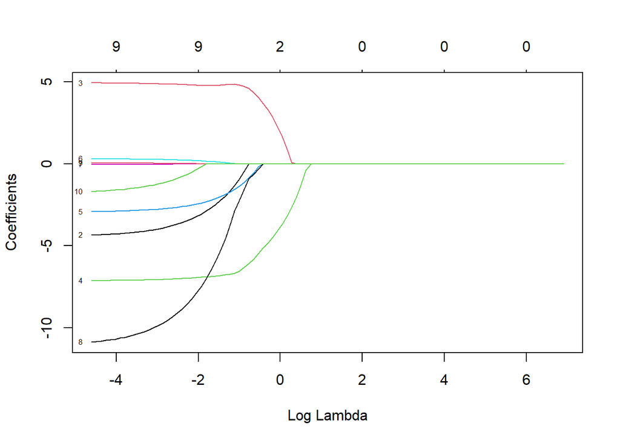

```r
lasso.mod <- glmnet(x.train, y.train, alpha=1, lambda=lambda.list.ridge)
plot(lasso.mod, xvar="lambda", label = TRUE)
```

We will now perform cross validation to find the best lamda and the MSE just like we did for ridge regression.

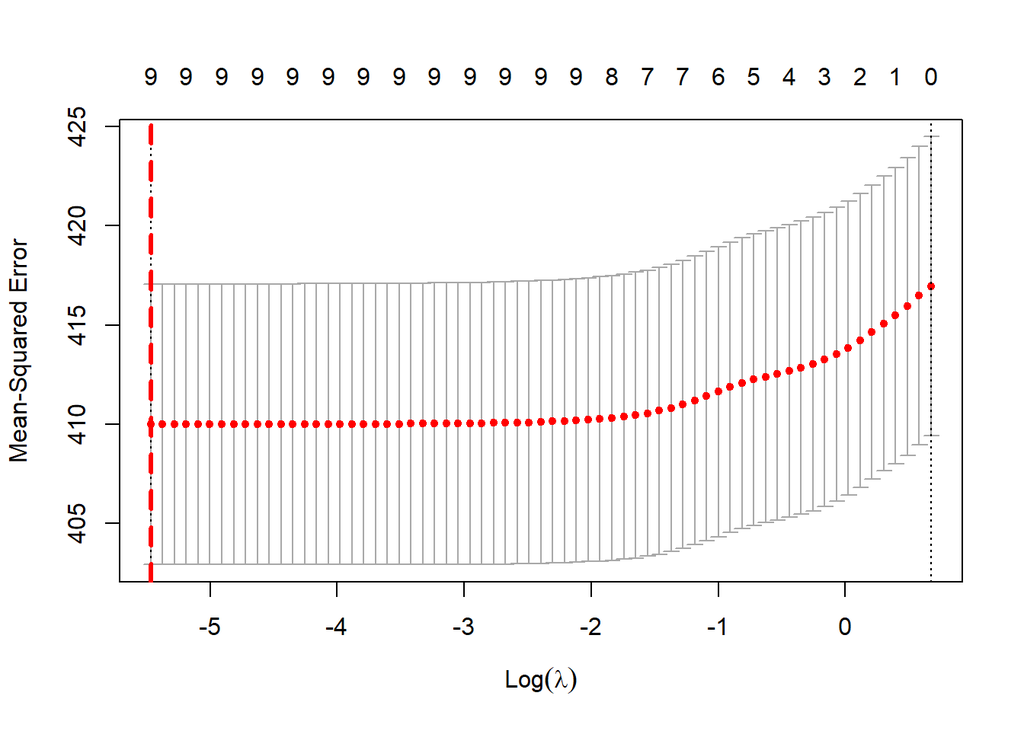

```r
set.seed(1)
cv.out.lasso = cv.glmnet(x.train, y.train, alpha = 1)
plot(cv.out.lasso)
abline(v = log(cv.out.lasso$lambda.min), col="red", lwd=3, lty=2)
```

The plot is showing the trend of mse according to our list of lamda. Our goal is to find the lamda that would give the lowest mse.

```r
bestlam_laso = cv.out.lasso$lambda.min
bestlam_laso
```

```
## [1] 0.004229973
```

The best lamda value for the laso regression to give the smallest MSE is 0.004229973

The laso testing MSE w/ best lamda

```r
lasso.pred = predict(lasso.mod, s = bestlam_laso, newx = x[test,])
mean((lasso.pred-y.test)^2)
```

```
## [1] 409.0363
```

The laso testing MSE with best lamda is 409.0363

The laso training MSE w/ best lamda

```r
lasso.pred = predict(lasso.mod, s = bestlam_laso, newx = x[train,])
mean((lasso.pred-y.train)^2)
```

```
## [1] 408.6969
```

The laso training MSE with best lamda is 408.6969

We see that the testing and training mse is similar to what we got in the linear regression and and ridge regression. We will now check the coefficient to see if whether any of them became zero. The coefficient that becomes 0 means that it have no/less assocaition to the resposne.

The Coefficient

```r
out=glmnet(x,y,alpha=1,lambda=lambda.list.ridge)
lasso.coef=predict(out,type="coefficients",s=bestlam_laso)
lasso.coef
```

```
## 11 x 1 sparse Matrix of class "dgCMatrix"
##                             s1
## (Intercept)       6.272548e+01
## (Intercept)       .
## acousticness     -3.849502e+00
## danceability      3.763175e+00
## instrumentalness -6.471817e+00
## liveness         -3.895751e+00
## loudness          4.788765e-01
## tempo            -1.628224e-02
## energy           -1.267016e+01
## key              -3.596704e-05
## speechiness      -2.174938e+00
```

None of the coefficients became zero, this means all the variables are associated with the response. However, we see that coefficient for key is extremely small.

# k-Nearest Neighbors regression

Training/Testing split

```r
Popularity_reg = data_4 %>%
  select(song_popularity, song_duration_ms, acousticness, danceability, energy, instrumentalness, liveness, loudness, speechiness, tempo,      audio_valence)
set.seed(123)
train = sample(1:nrow(Popularity_reg), 11240)
train.kreg = Popularity_reg[train,]
test.kreg = Popularity_reg[-train,]
y.train_kreg = train.kreg$song_popularity
x.train_kreg = train.kreg %>% select(-song_popularity) %>% scale(center = TRUE, scale = TRUE)
y.test_kreg = test.kreg$song_popularity
x.test_kreg = test.kreg %>% select(-song_popularity) %>% scale(center = TRUE, scale = TRUE)
```

We performed cross-validation that in a range of 1 to 100 and found that 47 is the best k value that would offer the lowest MSE. Hence, we will now proceed to find the training and testing MSE of the k-Nearest Neighbors regression.

Training MSE

```r
set.seed(12)
pred.y.train_kreg = knn.reg(train = x.train_kreg, test = x.train_kreg, y = y.train_kreg, k = 47)
mean((pred.y.train_kreg$pred - y.train_kreg)^2)
```

```
## [1] 387.3447
```

Testing MSE

```r
set.seed(13)
pred.y.test_kreg = knn.reg(train = x.train_kreg, test = x.test_kreg, y = y.train_kreg, k = 47)
mean((pred.y.test_kreg$pred - y.test_kreg)^2)
```

```
## [1] 402.0773
```

We see that the mse of knn regression is still relatively high, but it is lower than the linear regression model.

# Single decision tree

```r
library(tree)
```

```r
set.seed(131)
tree.music <- tree(song_popularity ~ . , data_4, subset=train_1)
summary(tree.music)
```

```
##
## Regression tree:
## tree(formula = song_popularity ~ ., data = data_4, subset = train_1)
## Variables actually used in tree construction:
## [1] "instrumentalness"
## Number of terminal nodes:  2
## Residual mean deviance:  409.4 = 4601000 / 11240
## Distribution of residuals:
##    Min. 1st Qu.  Median    Mean 3rd Qu.    Max.
## -51.540 -11.540   3.462   0.000  14.480  51.480
```

Plotting the tree

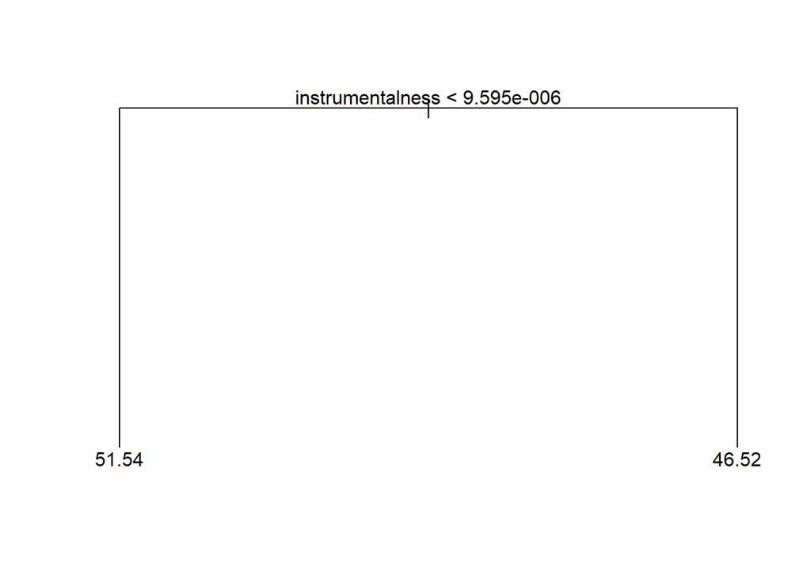

```r
plot(tree.music)
text(tree.music, pretty = 0)
```

Here we can see that the single tree does a split specifically on the instrumentalness of a track and assigns a weight based off the range of being less than or greater than 0.000009595. We’ll try to improve performance of this tree by pruning the tree below:

```r
cv.music <- cv.tree(tree.music)
```

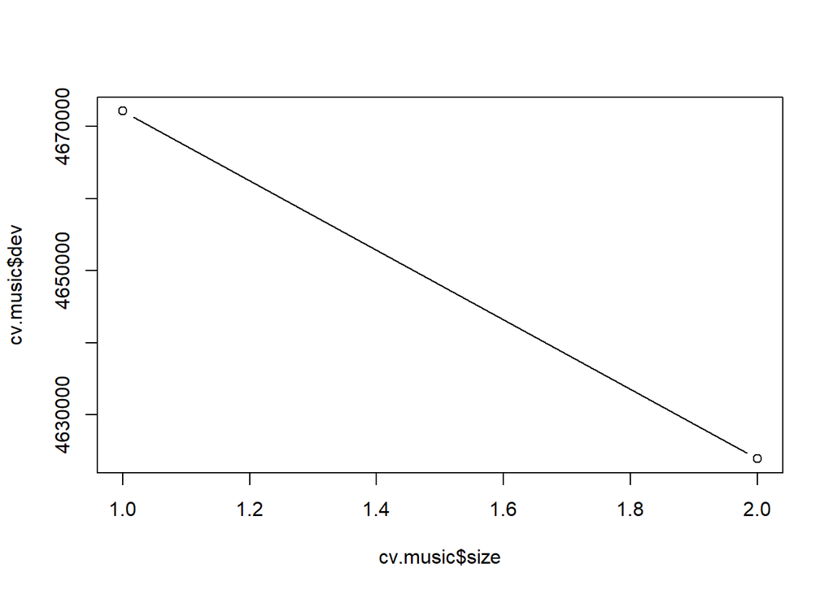

```r
plot(cv.music$size, cv.music$dev, type = "b")
```

Based off the above graph we see that the best size of the tree that gives the lowest cross-validation test error rate is 2 and so we’ll keep the tree with this size. Now let’s evaluate how this tree performs by calculating the test MSE.

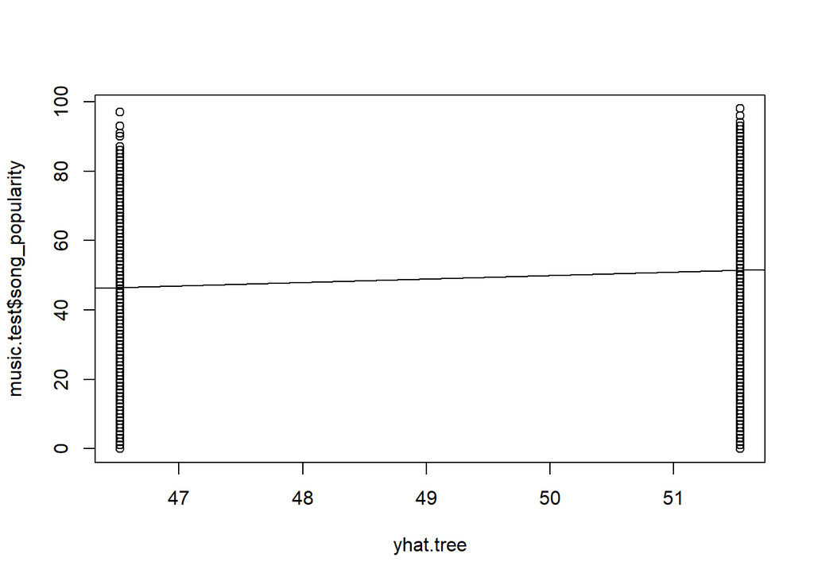

```r
yhat.tree <- predict(tree.music, newdata = data_4[-train_1,])
plot(yhat.tree, music.test$song_popularity)
abline(0,1)
```

```r
mean((yhat.tree - music.test$song_popularity)^2)
```

```
## [1] 415.7179
```

Here we see 2 values from our single tree predictions where the data points lie for each value in the test set so it’s consistent with the 2 nodes from our tree. Let’s see if we can improve model performance with another model, bagging and then we’ll move onto random forests!

# Bagging/Random Forest

Here we’re going to try building a random forest model but first we need the randomForest package.

```r
library(randomForest)
```

Here we build our first bagging model:

```r
set.seed(131)
#Perform bagging
bag.music <- randomForest(song_popularity ~ . , data = data_4, mtry=ncol(data_4) - 1,
                          importance=TRUE,subset=train_1)
bag.music
```

```
##
## Call:
##  randomForest(formula = song_popularity ~ ., data = data_4, mtry = ncol(data_4) -      1, importance = TRUE, subset = train_1)
##                Type of random forest: regression
##                      Number of trees: 500
## No. of variables tried at each split: 14
##
##           Mean of squared residuals: 401.4071
##                     % Var explained: 3.42
```

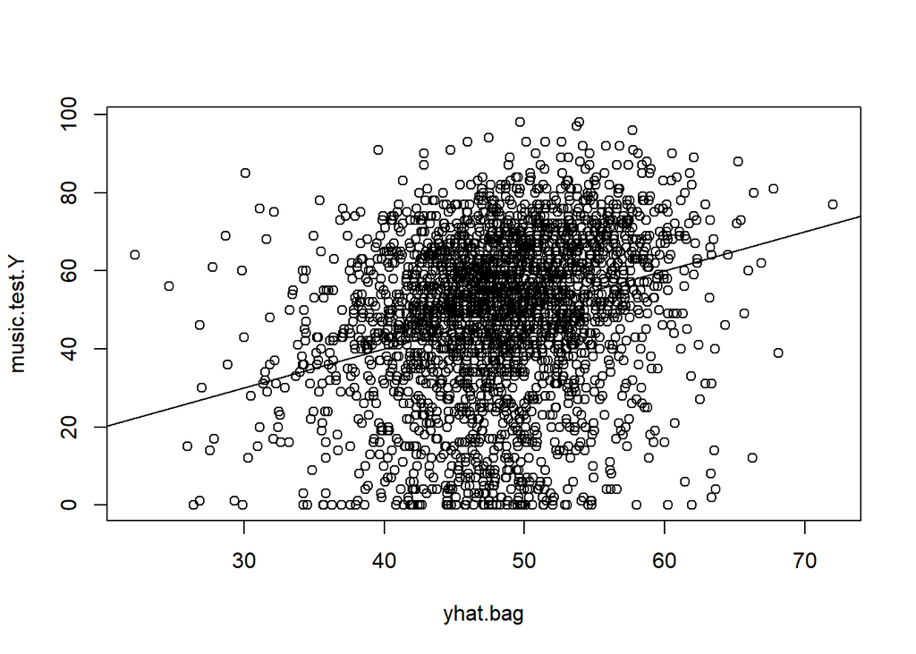

```r
yhat.bag <- predict(bag.music , newdata = data_4[-train_1,])
music.test.Y <- music.test$song_popularity
plot(yhat.bag, music.test.Y)
abline (0, 1)
```

```r
cat('MSE:',mean((yhat.bag - music.test.Y)^2))
```

```
## MSE: 400.5717
```

Based off the graph, it looks like we our bagged model is underestimating by about a popularity score of around 20 which matches our test MSE which is still pretty high for bagging. Still we see a 4% increase in performance compared to our single tree model. Let’s keep tuning our model with the number of predictors to use with random forests by starting with the a third or the default amount set for the randomForest function.

```r
set.seed(131)
#Here we create a random forest where we let mtry = p/3 or 14/3 or the default value
rf.music <- randomForest(song_popularity ~ . , data = data_4,
                          importance=TRUE,subset=train_1)
rf.music
```

```
##
## Call:
##  randomForest(formula = song_popularity ~ ., data = data_4, importance = TRUE,      subset = train_1)
##                Type of random forest: regression
##                      Number of trees: 500
## No. of variables tried at each split: 4
##
##           Mean of squared residuals: 399.3905
##                     % Var explained: 3.9
```

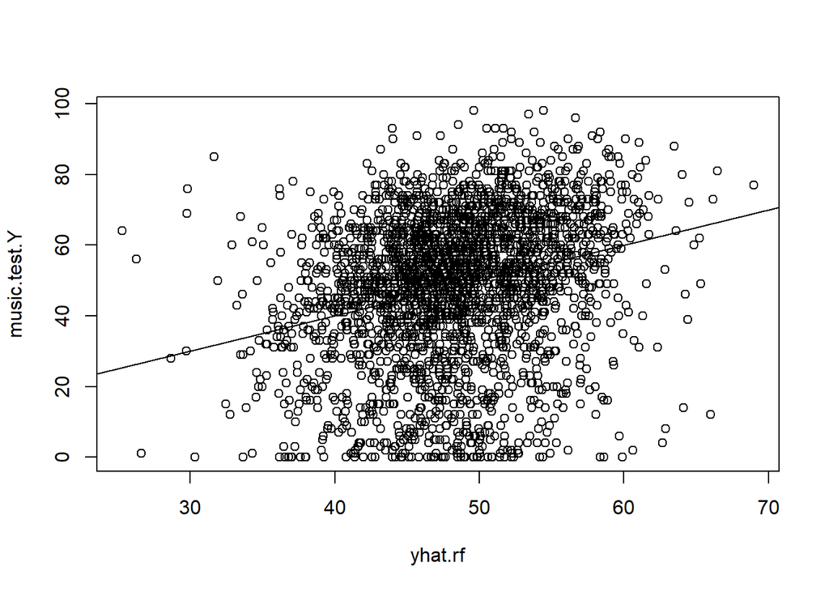

```r
yhat.rf <- predict(rf.music , newdata = data_4[-train_1,])
plot(yhat.rf, music.test.Y)
abline (0, 1)
```

```r
cat('MSE:',mean((yhat.rf - music.test.Y)^2))
```

```
## MSE: 397.6584
```

Checking the test set vs our predictions as we did with bagging and we still get a cluster of data points around the same area and so similar MSE. Here we tweak the number of variables for the random forest model to choose from in the splits

```r
set.seed(131)
#Here we create a random forest where we let mtry = 6
rf.music2 <- randomForest(song_popularity ~ . , mtry = 6,data = data_4,
                          importance=TRUE,subset=train_1)
rf.music2
```

```
##
## Call:
##  randomForest(formula = song_popularity ~ ., data = data_4, mtry = 6,      importance = TRUE, subset = train_1)
##                Type of random forest: regression
##                      Number of trees: 500
## No. of variables tried at each split: 6
##
##           Mean of squared residuals: 399.9277
##                     % Var explained: 3.77
```

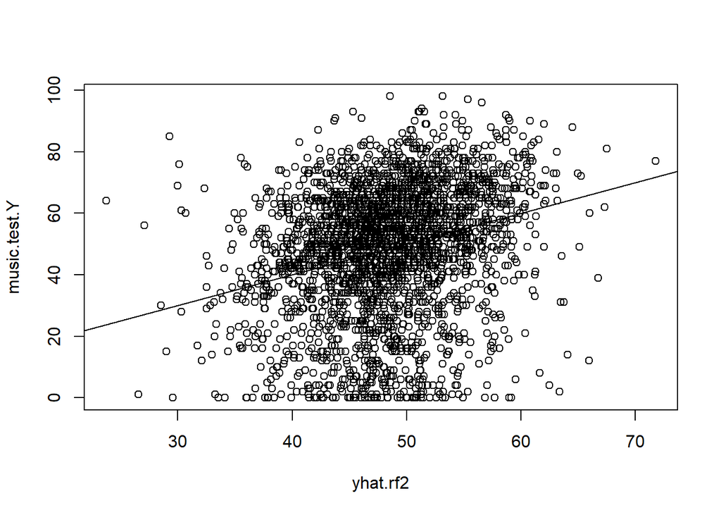

```r
yhat.rf2 <- predict(rf.music2 , newdata = data_4[-train_1,])
plot(yhat.rf2, music.test.Y)
abline (0, 1)
```

```r
cat('MSE:',mean((yhat.rf2 - music.test.Y)^2))
```

```
## MSE: 397.0418
```

With the MSE being more or less the same for bagging as it is in random forest, we will look to other methods but let’s analyze some of the predictors used in the model such as the increase in MSE for each variable.

```r
importance(rf.music)
```

```
##                     %IncMSE IncNodePurity
## song_name         1.6219851     352229.47
## song_duration_ms 12.6784242     382887.35
## acousticness     32.0227023     390099.09
## danceability     21.4288724     375276.32
## energy           41.9773031     369301.92
## instrumentalness 38.7270396     332151.87
## key              -0.6175931     192330.92
## liveness          8.6650696     358054.32
## loudness         36.8316078     399501.82
## audio_mode        3.0627506      44907.32
## speechiness      16.2758031     367736.60
## tempo            12.6171383     375471.16
## time_signature    2.6282495      28341.45
## audio_valence    23.1892796     376466.36
```

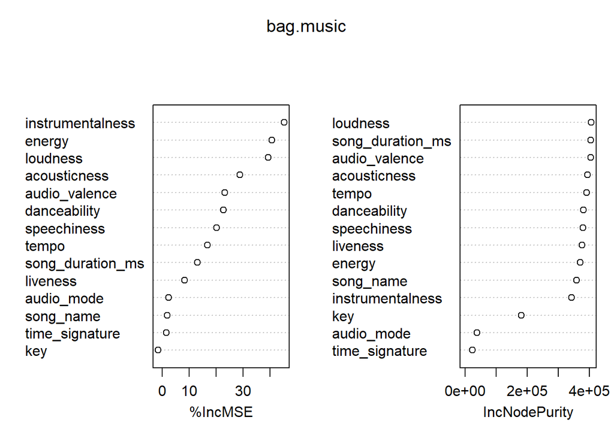

```r
varImpPlot(bag.music)
```

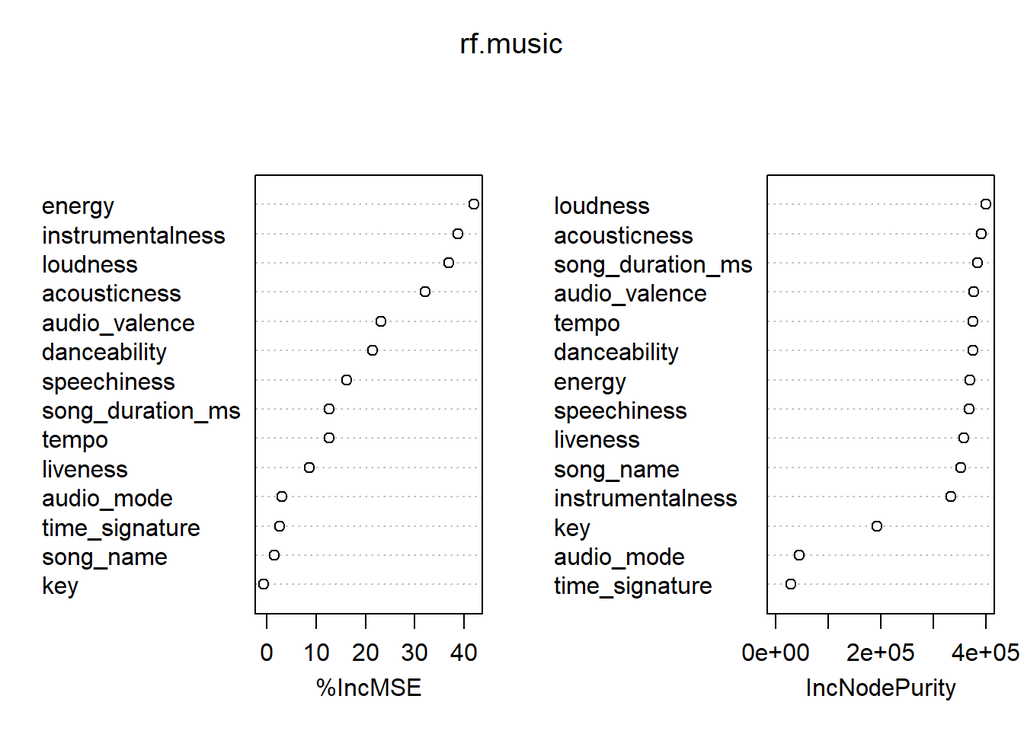

```r
varImpPlot(rf.music)
```

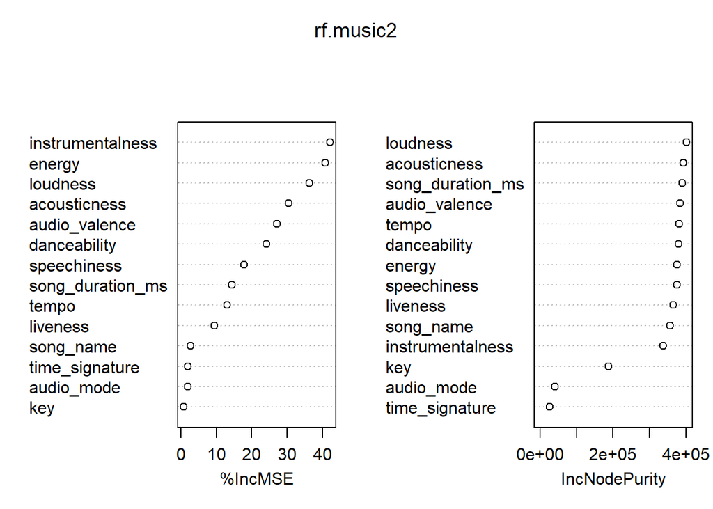

```r
varImpPlot(rf.music2)
```

Based off these plots we see the MSE increase with certain variables compared to others, namely, energy, instrumentalness, loudness, acousticness, audio_valence, and danceability. Both the bagging and random forest models share similar significant variables in the percent increase in mse such as instrumentalness, energy, and loudness. The node purity tells us how much a split with that variable reduces MSE and it looks like there the bagged and random forest model have similar variables namelly loudness, song duration, valence, and acousticness.

# Boosted trees

```r
library(gbm)
```

Here we build the first boosted tree model with a default shrinkage term of 0.1 to start off this section.

```r
set.seed(131)
boost.music <- gbm(song_popularity ~ . - song_name, data=data_4[train_1,],
                   distribution = "gaussian",
                   n.trees=5000,
                   interaction.depth = 4)
```

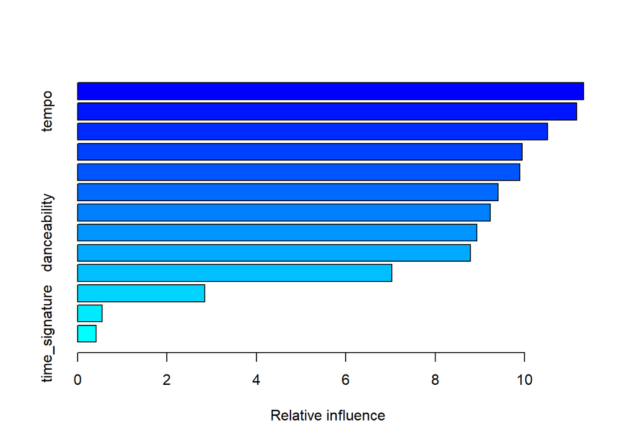

```
##                               var    rel.inf
## loudness                 loudness 11.3167912
## tempo                       tempo 11.1594260
## song_duration_ms song_duration_ms 10.5094993
## acousticness         acousticness  9.9434644
## speechiness           speechiness  9.8870924
## liveness                 liveness  9.4096231
## audio_valence       audio_valence  9.2313445
## danceability         danceability  8.9337021
## energy                     energy  8.7864671
## instrumentalness instrumentalness  7.0261449
## key                           key  2.8398648
## audio_mode             audio_mode  0.5444560
## time_signature     time_signature  0.4121243
```

```r
summary(boost.music)
```

We see the most important variables according to the boosted model is loudness, tempo, and song duration in milliseconds. Let’s take a look at the partial dependence for these 3 variables:

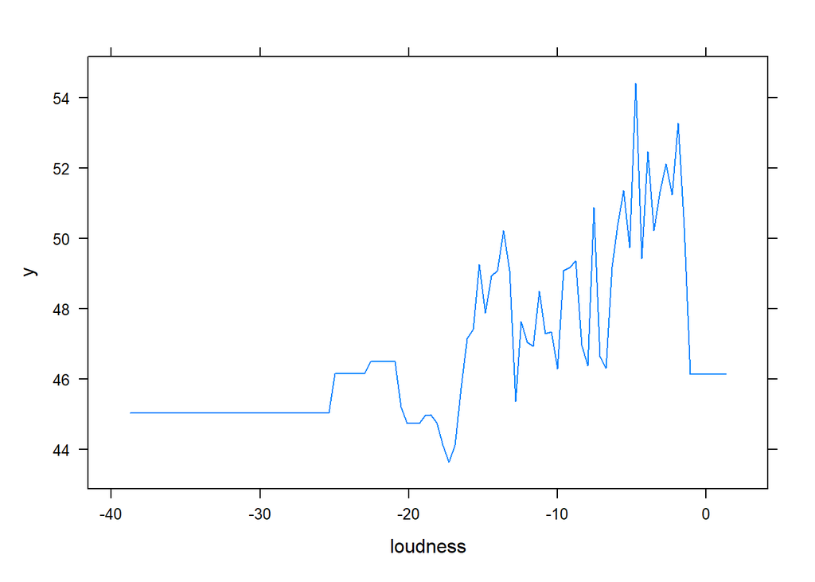

```r
plot(boost.music, i = 'loudness')
```

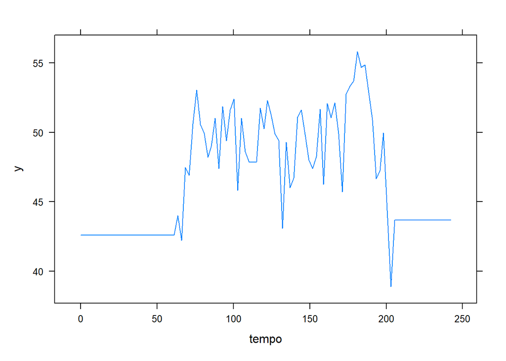

```r
plot(boost.music, i = 'tempo')
```